# 開発経済論期末試験

聖心女子大学国際交流学科  
2024年秋学期

## 1 子ども向け給付

アメリカには17歳未満の子どもがいる家庭への補助金給付(所得税還付child tax credit)があります。

- 補助金は会計年度(1月1日開始、12月31日終了)ごとに給付され、予算確保の都合上、申請するとその年ではなく翌会計年度1月1日から給付されます。
- 単純化のため、すべての子どもの親が産まれた当日に申請し、一回目の給付は1月1日と仮定します。

あなたはこの政策の担当者で、補助金給付が新生児の3歳時点での身長に与える効果を計測したいと考えています。あなたの手元には、2010-2011年に産まれたすべての子どもの誕生日、3歳時点での身長のデータが揃っています。

3歳時身長に対する新生児補助金給付のどのような効果ならば推計できるでしょうか。統御群をどのように設定するのかを明示して答えてください。[^1]また、推計した効果はどのような母集団に対する何の効果なのか、解釈を示してください。

<sup>1</sup> ヒント: この制度の特徴をうまく利用する推計方法を選んでください。

- 治療群=
- 統御群=
- 解釈: 母集団=、効果=

## 2 学費無償化

多くの国で初等教育は就学率が100%近くになっています。そこで就学率に関する次の目標は中等教育に移り、中等教育の学費を無償化する政府が増えています。

あなたはとある途上国の教育省高官です。この国ではすでに半分の州で学費無償化が実施されていますが、残り半分の州では実施されていません。学費無償化の就学率に与える効果を推計しようとしています。教育省は州ごとの就学率のデータを集めています。

1. 就学率に与える効果はどのようなデータを使ってどのように推計すればいいでしょうか。
2. 識別仮定を述べてください。
3. この推計方法とその結果が信頼できることを示すために、どのようなデータを使った仮説検定が必要ですか。
1. 推計方法
- 治療群=、統御群=

## 3 Baland and Robinson (2000) モデル: $h(\ell)=ah^{\frac{1}{2}}$

Baland, Jean-Marie, and James A. Robinson. 2000. “Is Child Labor Inefficient?” *Journal of Political Economy* 108 (4): 663–79. http://www.journals.uchicago.edu/cgi-bin/resolve?JPE008402PDF.

Baland and Robinson (2000) モデルで$h(\ell)=a\ell^{\frac{1}{2}}=a\sqrt{\ell}$と仮定します。簡単化のため、信用制約はないと仮定します。

1. 最適な就学時間を求めてください。[^2]
2. $a$が大きい人とはどのような人と解釈できるでしょうか。
3. $a$が大きい人と$a$が小さい人がいるとします。最適な$\ell$がより大きいのはどちらの人でしょうか。
4. 最適な$\ell$は$w$が上昇すると増えるでしょうか、それとも、減るでしょうか。増える・減るを示し、式を見てなぜかを説明してください。

<sup>2</sup> ヒント: 2つのFOCsを使って導出した関係式に$h(\ell)=a\ell^{\frac{1}{2}}$を当てはめて、$\ell=...$と解きます。微分の公式を参照してください。

## 4 クローニー・キャピタリズムと株価

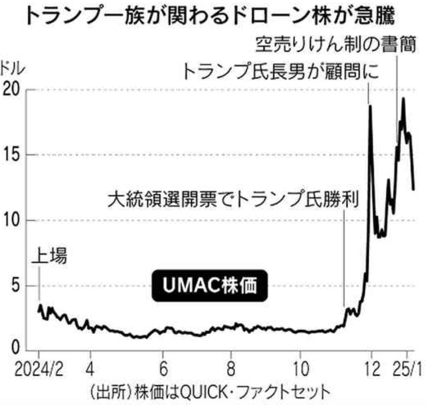

日経新聞1月11日(土)朝刊

<sup>3</sup> マルコス現大統領は前大統領の息子です。

独裁的な国家元首・与党にすり寄り、(競争からの)保護や腐敗(違法行為の見逃し)によって利潤を上げる企業が多い体制を縁故資本主義crony capitalism, cronyismといいます。かつてのフィリピンのマルコス前大統領体制が代表例です。[^3]利権を得ると利潤が増えるので、利権を得るとこうした企業の株価は上昇する傾向があります。

トランプ氏が大統領になるにあたり、長男のトランプ・ジュニア氏が選挙後の11月末に顧問に就任したドローン部品製造企業Unusual Machines (UMAC)と、同じく選挙後の12月にトランプ・ジュニア氏が取締役に就任した電子商取引企業PSQホールディングス(PSQH)の株価が急騰しています。

政権との癒着がこの2企業の株価に与える効果をどのように推計すれば良いでしょうか。推計方法、統御群の選定方法を明示して答えてください。

(参考)

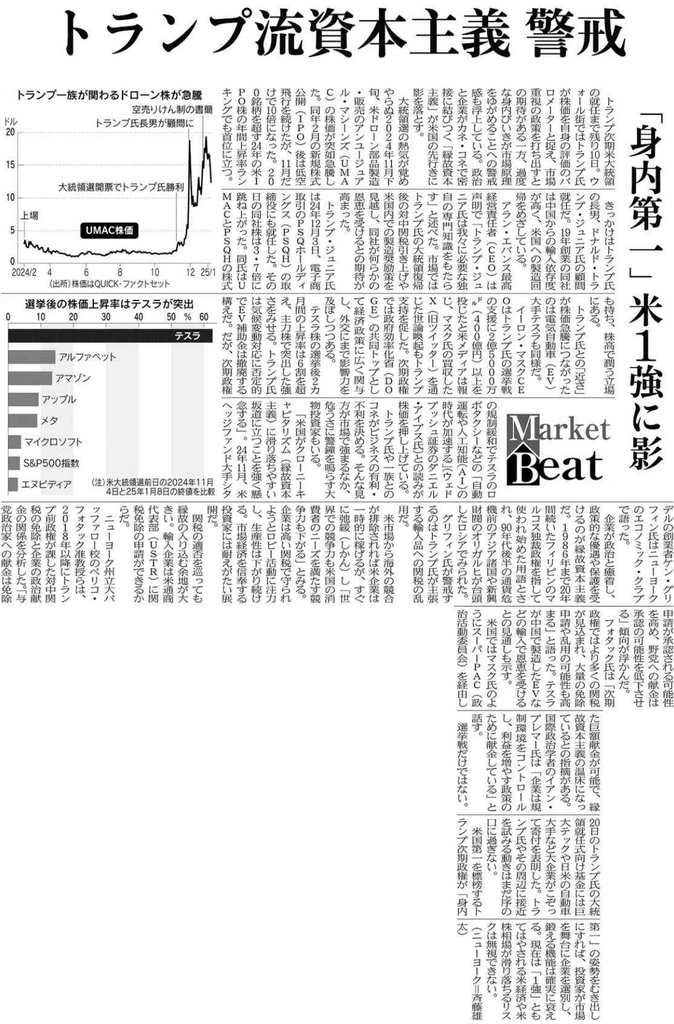

日経新聞1月11日(土)朝刊